# Cleaning Data Project

DataTrail Team

# Cleaning Data Project

## Set up

Let’s load these packages for use.

```r
## you can add more, or change...these are suggestions
library(tidyverse)
library(readr)
library(dplyr)
library(ggplot2)
library(tidyr)
```

## Set up directories

Here we are going to make a data directory if it doesn’t already exist.

```r
if (!dir.exists("data")) {
  dir.create("data")
}
```

## Get the data

We are going to use two different country datasets from Kaggle.

This UN data-derived dataset with various stats about different countries: https://www.kaggle.com/datasets/sudalairajkumar/undata-country-profiles The resulting CSV file is called `country_profile_variables.csv`.

This literacy dataset with statistics about literacy across countries https://www.kaggle.com/datasets/programmerrdai/literacy

The resulting CSV file is called `cross-country-literacy-rates`.

Both datasets have been downloaded and placed in the `data` and `raw` folder. Use readr::read_csv function to reach each dataset in. Call the first one `un_df` and the second `literacy_df`.

```r
# Read in the dataset for un_df
un_df <- read_csv(file.path("data", "raw", "country_profile_variables.csv"))
```

```r
# Read in the dataset for literacy_df
literacy_df <- read_csv(file.path("data", "raw", "cross-country-literacy-rates.csv"))
```

```r
colnames(un_df)
```

```
 [1] "country"
 [2] "Region"
 [3] "Surface area (km2)"
 [4] "Population in thousands (2017)"
 [5] "Population density (per km2, 2017)"
 [6] "Sex ratio (m per 100 f, 2017)"
 [7] "GDP: Gross domestic product (million current US$)"
 [8] "GDP growth rate (annual %, const. 2005 prices)"
 [9] "GDP per capita (current US$)"
[10] "Economy: Agriculture (% of GVA)"
[11] "Economy: Industry (% of GVA)"
[12] "Economy: Services and other activity (% of GVA)"
[13] "Employment: Agriculture (% of employed)"
[14] "Employment: Industry (% of employed)"
[15] "Employment: Services (% of employed)"
```

[output cut: 35 more lines]

```r
colnames(literacy_df)
```

```
[1] "Entity"
[2] "Code"
[3] "Year"
[4] "Literacy rates (World Bank, CIA World Factbook, and other sources)"
```

### Cleaning the datasets

You’ll notice both datasets have pretty messy looking column names that are annoying to use. Use the `janitor::clean_names()` function to clean these up.

```r
un_df <- janitor::clean_names(un_df)
literacy_df <- janitor::clean_names(literacy_df)
```

#### Clean up literacy_df

The `literacy_df` data frame shows multiple rows for each country. For this analysis, let’s only keep the latest year recorded for each country. You can use the `arrange()` and `distinct()` functions to do this.

```r
literacy_df <- literacy_df %>%
  arrange(-year) %>%
  distinct(entity, .keep_all = TRUE)
```

#### Clean up un_df

There’s a number of variables in `un_df` that are numeric but are being treated as a character.

Let’s take a look at `life_expectancy_at_birth_females_males_years` as an example. Use the `head()` function and print out the first 10 rows to see.

```r
head(un_df$life_expectancy_at_birth_females_males_years,
     n = 10)
```

```
 [1] "63.5/61.0" "79.9/75.6" "76.5/74.1" "77.8/71.1" "-99"       "63.0/57.4"
 [7] ".../..."   "78.2/73.3" "79.8/72.2" "77.0/70.6"
```

Two things we can notice here. One is that really it looks like this is two variables, one for female and one for male. We’ll want to split this into two columns.

Another is that they are using two different items to note missing data `-99` and `...` For R to deal with missing data appopriately we will want to change these to be `NA`.

Let’s start with the missing data. To replace these `-99` and `...` we can use the function: `naniar::replace_with_na()`. We’ll want to do this for every variable, not just the one we looked at above.

```r
un_df <- naniar::replace_with_na_all(un_df,
                                     condition = ~.x %in% c(-99, "-99", "...", ".../..."))
```

Let’s split the `life_expectancy_at_birth_females_males_years` column up into two columns so we can more appropriately deal with these data. To do this we can use a handy function called `tidyr::separate()`. Call the new resulting columns `life_expectancy_at_birth_females` and `life_expectancy_at_birth_males` by specifying this with the `into` argument.

```r
un_df <- un_df %>%
  separate(life_expectancy_at_birth_females_males_years,
           sep = "/",
           into = c("life_expectancy_at_birth_females",
                    "life_expectancy_at_birth_males"))
```

After splitting these data, you’ll notice they are still characters, so you will need to coerce them to numeric variables with a `mutate()` step.

In fact, there are a lot more columns like this. But for now just make these life_expectancy variables into numeric and don’t worry about the others.

```r
un_df <- un_df %>%
  mutate(life_expectancy_at_birth_females = as.numeric(life_expectancy_at_birth_females),
         life_expectancy_at_birth_males = as.numeric(life_expectancy_at_birth_males)
         )
```

The `un_df` has a `region` column.

Let’s run `summary` on it.

```r
summary(un_df$region)
```

```
   Length     Class      Mode
      229 character character
```

The regions listed are repeated but because they are characters, summary doesn’t give us useful information about the categories. This `region` columns would be best treated as factors. Turn this `region` column into a factor.

```r
un_df <- un_df %>%
  mutate(region = as.factor(region))
```

Re-run `summary` on your region columns to confirm that the data make more sense now.

```r
summary(un_df$region)
```

```
        Caribbean    CentralAmerica       CentralAsia     EasternAfrica
               25                 8                 5                19
      EasternAsia     EasternEurope         Melanesia        Micronesia
                7                10                 5                 7
     MiddleAfrica    NorthernAfrica   NorthernAmerica    NorthernEurope
                9                 7                 5                13
          Oceania         Polynesia South-easternAsia      SouthAmerica
                2                 9                11                14
   SouthernAfrica      SouthernAsia    SouthernEurope     WesternAfrica
                5                 9                16                16
      WesternAsia     WesternEurope
               18                 9
```

### Joining the data

Now we have two generally clean datasets that both have information about countries. Use a `dplyr::join` function to join all the rows for countries that are in both `un_df` and `literacy_df` but exclude rows from countries that aren’t in both. Look up `?dplyr::join` for more help. You will need to use the `by` argument.

Call this new data frame `countries_df`.

```r
countries_df <- inner_join(un_df, literacy_df,
                           by = c("country" = "entity"))
```

We will be returning to this dataset in a future project. Save `countries_df` to an RDS file here. Save this file to the `data` folder and name it “countries_df.rds”.

```r
write_rds(countries_df, file.path("data", "countries_df.rds"))
```

### Reshape data in preparation for plotting

We want to see how literacy is related to life expectancy. But have literacy split up by gender. Let’s reshape our data into something that will be easier to plot.

First, select only the following columns: `country`, `year`, `life_expectancy_at_birth_females`, `life_expectancy_at_birth_males`, and `literacy_rates_world_bank_cia_world_factbook_and_other_sources`. Name this new `select`ed data frame `plotting_df`.

In this same step, let’s also shorten the column name `literacy_rates_world_bank_cia_world_factbook_and_other_sources` to just `literacy_rates`.

```r
plotting_df <- countries_df %>%
  select(country,
         year,
         life_expectancy_at_birth_females,
         life_expectancy_at_birth_males,
         literacy_rates = literacy_rates_world_bank_cia_world_factbook_and_other_sources)
```

Now, let’s reshape this data so that it is longer. We will want a column for `gender` and one column for `life_expectancy`. Use the `tidyr::gather()` function.

```r
plotting_df <-
  gather(plotting_df,
       "gender",
       "life_expectancy",
       -literacy_rates, -country, -year)
```

You’ll notice your new column `gender` has the whole old variable name. We don’t really need all that. Use string manipulations so that you only have either `males` or `females`.

```r
plotting_df <- plotting_df %>%
  mutate(gender = str_remove(gender, "life_expectancy_at_birth_"))
```

## Plot the data!

Let’s make a plot of life expectancy and literacy rates!

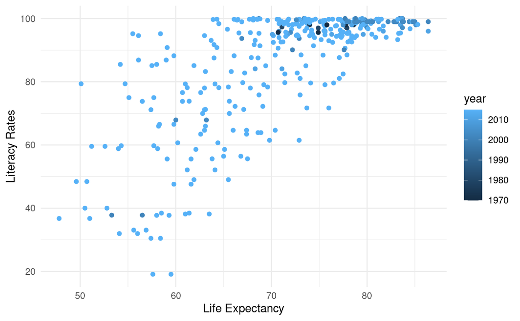

```r
lit_plot <- plotting_df %>%
  ggplot(aes(life_expectancy, literacy_rates, color = year)) +
  geom_point() +
  theme_minimal() +
  ylab("Literacy Rates") +
  xlab("Life Expectancy")

lit_plot
```

This looks like literacy and life expectancy are positively related to each other. In other words, in countries with higher literacy rates, there’s also a longer life expectancy.

In this plot we’ve color coded by the year that the literacy data was recorded. This way we are aware of how differences in years might influence this relationship.

But! Really, we’ve lumped together `female` and `male` data points with each country which isn’t really the right way to treat this data. Let’s use `facet_wrap()` to make this one plot into two separate plots.

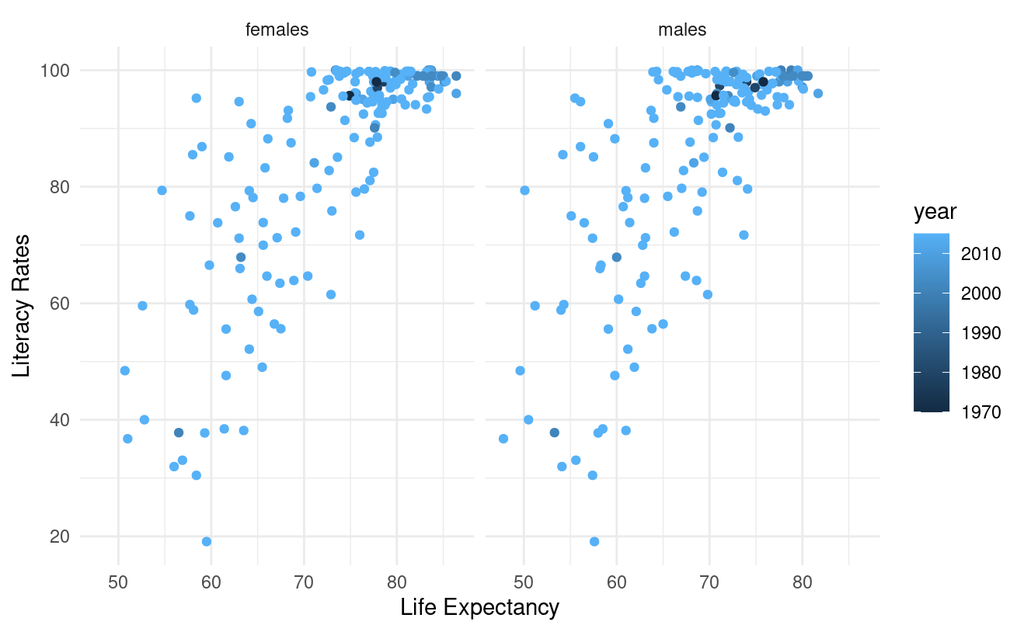

```r
lit_plot + facet_wrap(~gender)
```

It looks like this relationship is stable across `male` and `female`. Let’s get a stat on it.

## Get the stats

We can also use a correlation to ask this question.

```r
cor.test(countries_df$life_expectancy_at_birth_females,
         countries_df$literacy_rates_world_bank_cia_world_factbook_and_other_sources)
```

```
    Pearson's product-moment correlation

data:  countries_df$life_expectancy_at_birth_females and countries_df$literacy_rates_world_bank_cia_world_factbook_and_other_sources
t = 17.102, df = 175, p-value < 2.2e-16
alternative hypothesis: true correlation is not equal to 0
95 percent confidence interval:
 0.7284666 0.8404257
sample estimates:
      cor
0.7909772
```

```r
cor.test(countries_df$life_expectancy_at_birth_males,
         countries_df$literacy_rates_world_bank_cia_world_factbook_and_other_sources)
```

```
    Pearson's product-moment correlation

data:  countries_df$life_expectancy_at_birth_males and countries_df$literacy_rates_world_bank_cia_world_factbook_and_other_sources
t = 13.645, df = 175, p-value < 2.2e-16
alternative hypothesis: true correlation is not equal to 0
95 percent confidence interval:
 0.6380485 0.7825999
sample estimates:
      cor
0.7179783
```

With using either `male` or `female` this relationship looks pretty strong!

## Print out session info

Session info is a good thing to print out at the end of your notebooks so that you (and other folks) referencing your notebooks know what software versions and libraries you used to run the notebook.

[session information not shown]